# 成為初級資料分析師 | Python 程式設計

> 專題：房屋貸款試算器

## 郭耀仁

## 大綱

- 關於房屋貸款
- 月還款金額、本金與利息
- 房屋淨值與景氣預測

## 關於房屋貸款

## 房屋貸款 = 房價 - 頭期款

- 常見的頭期款比例為 20%
- 常見的貸款期間為 20 年

## 例如購買 1000 萬元的房屋

- 20% 頭期款
- 80% 房屋貸款，分 20 年（240 個月）償還

```python
home_value = 10000000
down_payment_percent = 0.2
down_payment = home_value * down_payment_percent
morgage_loan = home_value - down_payment
print("頭期款 ${:,}".format(down_payment))
print("房屋貸款 ${:,}".format(morgage_loan))
```

```
頭期款 $2,000,000.0
房屋貸款 $8,000,000.0
```

## 房貸利率通常以年利率表示，在計算月還款時應以月利率計算

$$R_{monthly} = (1 + R_{yearly})^{1/12} - 1$$

## 使用 NumPy 套件提供的 `pmt(rate, nper, pv)` 函數可以計算月還款

- `rate` 月利率
- `nper` 期數
- `pv` 房屋貸款

## 例如 20 年償還 800 萬年利率為 1.98% 的房屋貸款

```python
import numpy as np

monthly_rate = (1 + 0.0198)**(1/12) - 1
monthly_payment = np.pmt(rate=monthly_rate, nper=12*20, pv=8000000)
print(monthly_payment)
```

```
-40327.81784956683
```

## 作業：寫作函數 `get_monthly_payment(home_value, mortgage_ratio, yearly_rate, n_years)`

- `home_value` 房價
- `mortgage_ratio` 房屋貸款成數
- `yearly_rate` 房屋貸款利率
- `n_years` 貸款期間

```python
get_monthly_payment(10000000, 0.8, 0.0198, 20)
```

```
40327.81784956683
```

## 月還款金額、本金與利息

## 月還款金額 = 房屋貸款利息 + 房屋貸款本金

- 房屋貸款利息

$$\text{Interest Payment} = \text{Mortgage Balance} \times R_{monthly}$$

- 房屋貸款本金

$$\text{Principal Payment} = \text{Monthly Payment} - \text{Interest Payment}$$

## 計算第一個月的還款金額中利息與本金分別為？

```python
monthly_payment = get_monthly_payment(10000000, 0.8, 0.0198, 20)
mortgage_loan = 8000000
monthly_rate = (1 + 0.0198)**(1/12) - 1
first_interest_payment = round(mortgage_loan * monthly_rate, 2)
first_principal_payment = round(monthly_payment - first_interest_payment, 2)
print("第一個月的還款金額中房屋貸款利息為: ${:,}".format(first_interest_payment))
print("第一個月的還款金額中房屋貸款本金為: ${:,}".format(first_principal_payment))
```

```
第一個月的還款金額中房屋貸款利息為: $13,081.7
第一個月的還款金額中房屋貸款本金為: $27,246.12
```

## 計算每一期的房屋貸款餘額、房屋貸款本金、利息並記錄在 `list` 中

```python
monthly_payment = get_monthly_payment(10000000, 0.8, 0.0198, 20)
mortgage_loan = 8000000
monthly_rate = (1 + 0.0198)**(1/12) - 1
payment_periods = 20*12
principal_balance, interest_payments, principal_payments = [], [], []
for i in range(payment_periods):
    if i == 0:
        principal_remained = mortgage_loan
    else:
        principal_remained = principal_balance[i - 1]
    interest_payment = np.round(principal_remained*monthly_rate, 2)
    principal_payment = np.round(monthly_payment-interest_payment, 2)
    # At the end of payment
    if principal_remained < principal_payment:
        principal_payment = round(principal_remained, 2)
    principal_bal = round(principal_remained - principal_payment, 2)
    principal_balance.append(principal_bal)
    interest_payments.append(interest_payment)
    principal_payments.append(principal_payment)
```

## 作業：寫作函數 `get_monthly_details(home_value, mortgage_ratio, yearly_rate, n_years)`

```python
principal_balance, interest_payments, principal_payments = get_monthly_details(10000000, 0.8, 0.0198, 20)
print(principal_balance[-5:])
print(interest_payments[-5:])
print(principal_payments[-5:])
```

```
[160653.3, 120588.18, 80457.55, 40261.3, 0.0]
[328.11, 262.7, 197.19, 131.57, 65.84]
[39999.71, 40065.12, 40130.63, 40196.25, 40261.3]
```

## （補充）視覺化觀察房屋貸款本金與房屋貸款利息的變化

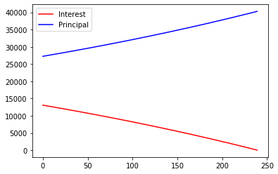

```python
import matplotlib.pyplot as plt
%matplotlib inline

plt.plot(interest_payments, color="red", label="Interest")
plt.plot(principal_payments, color="blue", label="Principal")
plt.legend(loc=2)
plt.show()
```

## 房屋淨值與景氣預測

## 房屋淨值擁有權（Home equity owned）指的是某個時間點，房貸戶所真正擁有的房屋淨值比例

$$ \text{Home Equity Owned} = \text{Down Payment Percent} + \frac{E_{cumulative, t}}{\text{Home Value}} \\ E_{cumulative, t} = \sum_t{\text{Principal Payment}} $$

## 使用 NumPy 套件提供的累計加總函數 `np.cumsum()`

## 計算房貸戶每一期的房屋淨值所有權

```python
home_value = 10000000
down_payment_percent = 0.2
principal_balance, interest_payments, principal_payments = get_monthly_details(home_value, 1-down_payment_percent, 0.0198, 20)
cumulative_home_equity = np.cumsum(principal_payments)
cumulative_percent_owned = 0.2 + (cumulative_home_equity / home_value)
print(cumulative_percent_owned[:5])
print(cumulative_percent_owned[-5:])
```

```
[0.20272461 0.20545368 0.20818721 0.21092521 0.21366769]
[0.98393467 0.98794118 0.99195424 0.99597387 1.        ]
```

## （補充）視覺化觀察房屋貸款本金與房屋貸款利息累計加總的變化

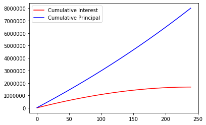

```python
cumulative_interest_paid = np.cumsum(interest_payments)
plt.plot(cumulative_interest_paid, color='red', label="Cumulative Interest")
plt.plot(cumulative_home_equity, color='blue', label="Cumulative Principal")
plt.legend(loc=2)
plt.show()
```

## 景氣預測：預期房價每個月上漲 0.25%

## 使用 NumPy 套件提供的累計乘積函數 `np.cumprod()`

```python
growth_arr = [1.0025 for i in range(240)]
cumulative_growth_forecast = np.cumprod(growth_arr)
home_value_forecast = home_value * cumulative_growth_forecast
cumulative_home_value_owned = cumulative_percent_owned * home_value_forecast
```

## （補充）視覺化觀察房價與房屋淨值擁有的變化

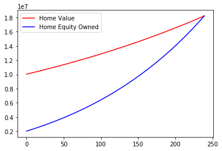

```python
plt.plot(home_value_forecast, color='red', label="Home Value")
plt.plot(cumulative_home_value_owned, color='blue', label="Home Equity Owned")
plt.legend(loc=2)
plt.show()
```

## 景氣預測：預期房價每個月下跌 0.25%

```python
decline_arr = [1- 0.0025 for i in range(240)]
cumulative_decline_forecast = np.cumprod(decline_arr)
home_value_forecast = home_value * cumulative_decline_forecast
cumulative_home_value_owned = cumulative_percent_owned * home_value_forecast
```

## （補充）視覺化觀察房價與房屋淨值擁有的變化

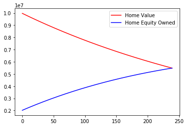

```python
plt.plot(home_value_forecast, color='red', label="Home Value")
plt.plot(cumulative_home_value_owned, color='blue', label="Home Equity Owned")
plt.legend(loc=1)
plt.show()
```